# Unstructured text analysis on the Dark Knight trilogy

Unstructured text analysis on the Dark Knight trilogy Karola Takács 20/05/2021

In this assignment my main aim is to investigate how the Dark Knight trilogy episodes’ sentiment vary and my hypothesis is that the newer the episode the more negative it gets to attract the viewers and to excel the previous one.

### Import and transform text files

Reading in the first txt file, which is the subtitle for Batban Begins.

```r
text <- read_tsv("begins_eng.txt", col_names = TRUE, trim_ws = TRUE, skip_empty_rows = TRUE)

# get rid of numbers and non-letters
text <-
  text %>% filter(str_detect(text, "[a-z]|[A-Z]"))

n = nrow(text)
vec  <- as.vector(text$text)

# put the text into dataframe
begins_df <- tibble(line = 1:n, text = vec)

# apply unnest function to have a one word per line format
begins_tidy <- begins_df %>%
  unnest_tokens(word, text)

# get rid of stop word, common words
begins_tidy <- begins_tidy %>%
  anti_join(stop_words, by = "word")
```

I might need to remove some words that are not important or are not consistent with their sentiment To check this, I am joining my tidy data with the Bing lexicon to check sentiments, especially since later I am going to use the Bing dictionary for the word clouds as well.

```r
bing_word_count_a <- begins_tidy %>%
   inner_join(get_sentiments("bing")) %>%
   count(word, sentiment, sort=TRUE) %>%
   ungroup() %>%
   head(15)

bing_word_count_a
```

```
## # A tibble: 15 x 3
##    word     sentiment     n
##    <chr>    <chr>     <int>
##  1 fear     negative     21
##  2 master   positive     14
##  3 dead     negative      9
##  4 lost     negative      9
##  5 afraid   negative      8
##  6 chill    negative      8
##  7 fine     positive      8
##  8 hell     negative      8
##  9 anger    negative      7
## 10 crime    negative      7
## 11 criminal negative      7
## 12 happy    positive      6
## 13 kill     negative      6
## 14 miss     negative      6
## 15 nice     positive      6
```

Master is a positive word and in this case it signals some subordinate relationship, but in this case it is more of the sign of respect and indication of service to someone. Some combinations are misleading, e.g. master bedroom which is neither positive nor negative. At this point I decided not to remove Chill and Crane since they are characters, but later I need to since those words have negative sentiment.

```r
# my own list to exclude words
words_to_ignore_begins <- data_frame(word = c("sir", "master"))

begins_tidy <- begins_tidy %>%
   anti_join(words_to_ignore_begins, by = "word")

begins_tidy %>%
  count(word, sort = TRUE) %>%  head(10)
```

```
## # A tibble: 10 x 2
##    word        n
##    <chr>   <int>
##  1 bruce      62
##  2 wayne      50
##  3 people     30
##  4 rachel     28
##  5 gotham     26
##  6 gordon     22
##  7 fear       21
##  8 crane      20
##  9 falcone    19
## 10 batman     18
```

There seems to be very few unique words in the dialogues, now that I removed stopwords. Taking a look at the most frequent words in the first episode: Not surprisingly ‘bruce wayne’ is much ahead, but ‘people’ and ‘gotham’ appear a lot of times in the text, so it is important where the plot happens.

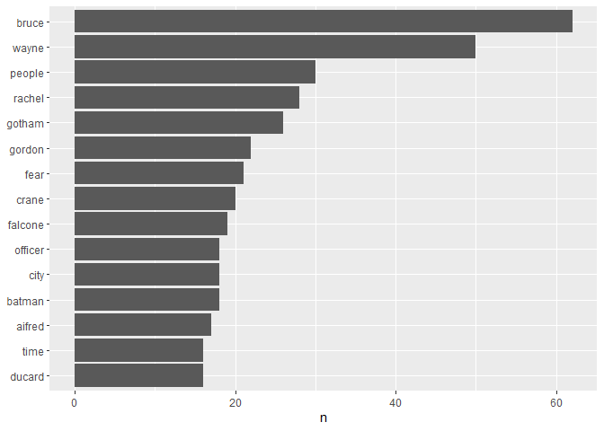

Reading in the second txt file, which is the subtitle for The Dark Knight.

```r
# same steps
text <- read_tsv("dark_knight_eng.txt", col_names = TRUE, trim_ws = TRUE, skip_empty_rows = TRUE)

text <-
    text %>% filter(str_detect(text, "[a-z]|[A-Z]"))

n = nrow(text)
vec  <- as.vector(text$text)

dk_df <- tibble(line = 1:n, text = vec)

dk_tidy <- dk_df %>%
    unnest_tokens(word, text)

dk_tidy <- dk_tidy %>%
    anti_join(stop_words, by = "word")

# remove rows with remaining numbers - for some reason I could not fix this issue, so I applied this simple filter to get rid of the numbers
dk_tidy = filter(dk_tidy, line != "2174")

# again check with bing:
bing_word_count_b <- dk_tidy %>%
   inner_join(get_sentiments("bing")) %>%
   count(word, sentiment, sort=TRUE) %>%
   ungroup() %>%
   head(15)

bing_word_count_b
```

```
## # A tibble: 15 x 3
##    word   sentiment     n
##    <chr>  <chr>     <int>
##  1 dent   negative     47
##  2 joker  negative     27
##  3 kill   negative     17
##  4 hero   positive     15
##  5 die    negative     12
##  6 trust  positive     12
##  7 blow   negative     10
##  8 dead   negative     10
##  9 hurt   negative      8
## 10 killed negative      8
## 11 ready  positive      8
## 12 love   positive      7
## 13 nice   positive      7
## 14 pretty positive      7
## 15 fair   positive      6
```

Dent also means ‘punch’ or ‘beat’ but it is the name of a character - Harvey Dent - who turns into bad in the movie. Also, despite being the secondary antagonist, he became the final antagonist of the film after Joker’s defeat. In this case the name is indicative of the character, but should be removed from the word list. Here I am leaving it in, since this also signals that the story is very character-based. I was also wondering why joker is negative: I think it can also have a positive angle: it can be considered as the most valuable card in some card games and in that case Joker refers to a funny figure. Not sure what the Bing lexicon creators thought of Joker. :)

```r
# Remove words 'Wanna' and 'yeah' as these rather look like filling words, and slang grammar
words_to_ignore_dk <- data_frame(word = c("sir", "master","wanna", "yeah", "gonna"))

dk_tidy <- dk_tidy %>%
   anti_join(words_to_ignore_dk, by = "word")

dk_tidy %>%
    count(word, sort = TRUE) %>%  head(10)
```

```
## # A tibble: 10 x 2
##    word       n
##    <chr>  <int>
##  1 harvey    72
##  2 dent      47
##  3 batman    42
##  4 people    34
##  5 rachel    34
##  6 gotham    29
##  7 joker     27
##  8 wayne     26
##  9 time      23
## 10 money     20
```

Harvey Dent takes over in the second episode along ‘batman’, while ‘wayne’ got even behind Joker. Not much verbs here, the first one appearing is ‘kill’.

[figure not shown]

Reading in the third txt file, which is the subtitle for The Dark Knight Rises

```r
# same steps
text <- read_tsv("dk_rises_eng.txt", col_names = TRUE, trim_ws = TRUE, skip_empty_rows = TRUE)

text <-
    text %>% filter(str_detect(text, "[a-z]|[A-Z]"))

n = nrow(text)
vec  <- as.vector(text$text)

dk_rises_df <- tibble(line = 1:n, text = vec)

dk_rises_tidy <- dk_rises_df %>%
    unnest_tokens(word, text)

dk_rises_tidy <- dk_rises_tidy %>%
    anti_join(stop_words, by = "word")

# Check with bing
bing_word_count_c <- dk_rises_tidy %>%
   inner_join(get_sentiments("bing")) %>%
   count(word, sentiment, sort=TRUE) %>%
   ungroup() %>%
   head(15)

bing_word_count_c
```

```
## # A tibble: 15 x 3
##    word     sentiment     n
##    <chr>    <chr>     <int>
##  1 bane     negative     38
##  2 bomb     negative     21
##  3 dent     negative     18
##  4 die      negative     13
##  5 hell     negative     11
##  6 death    negative     10
##  7 miss     negative     10
##  8 fear     negative      9
##  9 kill     negative      9
## 10 powerful positive      9
## 11 master   positive      8
## 12 afraid   negative      7
## 13 clean    positive      7
## 14 dead     negative      7
## 15 died     negative      7
```

Again, Bane - a character - means strike, trouble and the like. It has a negative sentiment. For the frequency of the words I am leaving it in the text but later I am going to remove it (before creating the sentiment graph). It is interesting what names the writers choose, so the anti-hero’s name reflects its personality and role.

```r
# Adding words 'uh' and 'hey' to my exception list as these are meaningless
words_to_ignore_dk_rises <- data_frame(word = c("uh", "hey","sir", "master","wanna", "yeah", "gonna"))

dk_rises_tidy <- dk_rises_tidy %>%
    anti_join(words_to_ignore_dk_rises, by = "word")

dk_rises_tidy %>%
    count(word, sort = TRUE) %>%  head(10)
```

```
## # A tibble: 10 x 2
##    word       n
##    <chr>  <int>
##  1 wayne     61
##  2 bane      38
##  3 people    36
##  4 time      28
##  5 city      27
##  6 gotham    25
##  7 bruce     24
##  8 bomb      21
##  9 batman    18
## 10 dent      18
```

‘Time’ got a more prominent place in terms of ranking and ‘wayne’ is again the first in terms of frequency. Similarly: storyline is about characters and the city / people.

[figure not shown]

```r
# visualize most common words in the third episode

dk_rises_tidy %>%
    count(word, sort = TRUE) %>%
    filter(n > 15) %>%
    mutate(word = reorder(word, n)) %>%
    ggplot(aes(word, n)) + geom_col() + xlab(NULL) + coord_flip()
```

```r
word_frequency <- bind_rows(mutate(begins_tidy, episode = "Batman Begins (2005)"),
                            mutate(dk_tidy, episode = "The Dark Knight (2008)"),
                            mutate(dk_rises_tidy, episode = "The Dark Knight Rises (2012)")) %>%
   count(episode, word) %>%
   group_by(episode) %>%
   mutate(proportion = n / sum(n)) %>%
   select(-n) %>%
   spread(episode, proportion) %>%
   gather(episode, proportion, `The Dark Knight (2008)`:`The Dark Knight Rises (2012)`)
```

Visualizing the proportion of words occurring in Batman Begins to the words in The Dark Knight and to The Dark Knight Rises. Words close to the line have similar frequencies in both texts

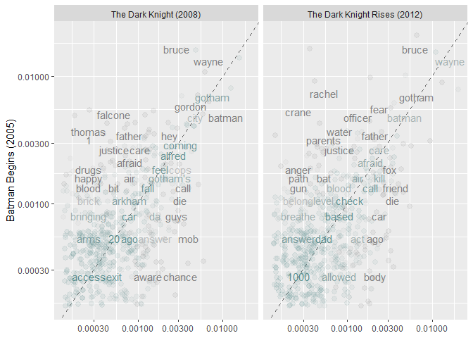

```r
ggplot(word_frequency, aes(x = proportion, y =`Batman Begins (2005)`, color = abs(`Batman Begins (2005)` - proportion))) +
   geom_abline(color = "gray40", lty = 2) +
   geom_jitter(alpha = 0.1, size = 2.5, width = 0.3, height = 0.3) +
   geom_text(aes(label = word), check_overlap = TRUE, vjust = 1.5) +
   scale_x_log10(labels = label_number())+
   scale_y_log10(labels = label_number()) +
   scale_color_gradient(limits = c(0, 0.001), low = "darkslategray4", high = "gray75") +
   facet_wrap(~episode, ncol = 2) +
   theme(legend.position="none") +
   labs(y = "Batman Begins (2005)", x = NULL)
```

Based on the graphs we see that there is not much variation, it seems the texts have rather small corpus. ‘Drugs’ and ‘blood’ and ‘falcone’ have higher frequency in the first episode than in the second and ‘batman’ is more frequent in the second episode than in the first. Rachel appears more often in the first than in the last episode (since she dies in the second episode)

## Word clouds

[figure not shown]

```r
library(wordcloud)

begins_tidy %>%
   anti_join(stop_words) %>%
   count(word) %>%
   with(wordcloud(word, n, max.words = 100))
```

[figure not shown]

```r
# defining words: bruce, wayne, rachel, people

dk_tidy %>%
   anti_join(stop_words) %>%
   count(word) %>%
   with(wordcloud(word, n, max.words = 100))
```

[figure not shown]

```r
# defining words: harvey, batman, people

dk_rises_tidy %>%
   anti_join(stop_words) %>%
   count(word) %>%
   with(wordcloud(word, n, max.words = 100))
```

```r
# defining words: wayne, bane, people, time
```

With adding the Bing lexicon to the clouds we can inspect them by positive and negative sentiment. The first episode is dominated by fear - fine, the second with kill - hero and the third with powerful - bomb, which could be extremely negative if that is a ‘powerful bomb’. :) I will get to bigrams a bit later.

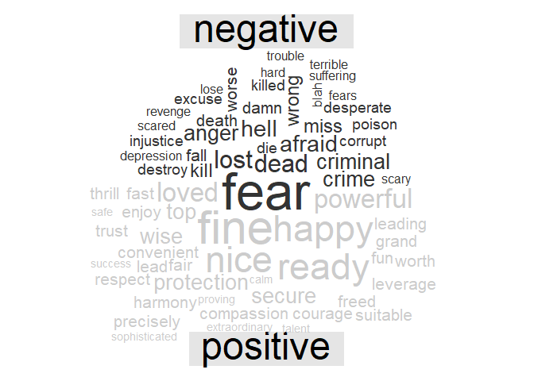

```r
# Word cloud sorted by sentiments
library(reshape2)
library(textdata)

# first I remove the family names, so they won't appear either positive or negative (mostly negative)

wti <- data_frame(word = c("chill", "dent", "joker","bane"))

begins_tidy <- begins_tidy %>%
   anti_join(wti, by = "word")

begins_tidy %>%
   inner_join(get_sentiments("bing")) %>%
   count(word, sentiment, sort = TRUE) %>%
   acast(word ~ sentiment, value.var = "n", fill = 0) %>%
   comparison.cloud(colors = c("gray20", "gray80"),
                    max.words = 70)
```

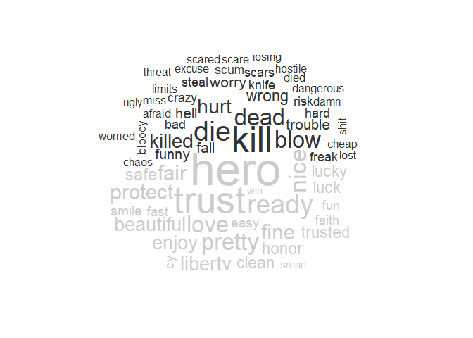

```r
# I don't want to skew the plot with Joker so I remove it. For me does not really feel that negative however for the bing lexicon's creator it has been.

dk_tidy <- dk_tidy %>%
   anti_join(wti, by = "word")


dk_tidy %>%
   inner_join(get_sentiments("bing")) %>%
   count(word, sentiment, sort = TRUE) %>%
   acast(word ~ sentiment, value.var = "n", fill = 0) %>%
   comparison.cloud(colors = c("gray20", "gray80"),
                    max.words = 70)
```

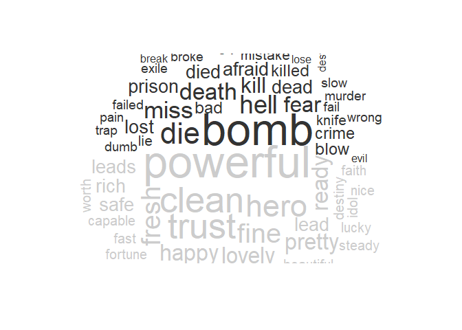

```r
dk_rises_tidy <- dk_rises_tidy %>%
   anti_join(wti, by = "word")

dk_rises_tidy %>%
   inner_join(get_sentiments("bing")) %>%
   count(word, sentiment, sort = TRUE) %>%
   acast(word ~ sentiment, value.var = "n", fill = 0) %>%
   comparison.cloud(colors = c("gray20", "gray80"),
                    max.words = 70)
```

## Sentiment Analysis

```r
# introduce linenumber as a new column, like this each row will have a different linenumber, which will be the index for the word in that row

begins_tidy_row <- begins_tidy %>%
  mutate(
      linenumber = row_number())

dk_tidy_row <- dk_tidy%>%
   mutate(
      linenumber = row_number())

dk_rises_tidy_row <- dk_rises_tidy %>%
   mutate(
      linenumber = row_number())

# I am going to use afinn sentiment lexicon since this one will be most suitable later on
# choose 30 as a meaningful chunk to check sentiment on, since I have small texts.

afinn_begins <- begins_tidy_row %>%
   inner_join(get_sentiments("afinn")) %>%
   group_by(index = linenumber %/% 30) %>%
   summarize(sentiment = sum(value)) %>%
   mutate(episode = "Batman Begins")

afinn_dk <- dk_tidy_row %>%
   inner_join(get_sentiments("afinn")) %>%
   group_by(index = linenumber %/% 30) %>%
   summarize(sentiment = sum(value)) %>%
   mutate(episode = "The Dark Knight")

afinn_dk_rises <- dk_rises_tidy_row %>%
   inner_join(get_sentiments("afinn")) %>%
   group_by(index = linenumber %/% 30) %>%  # row_number()
   summarize(sentiment = sum(value)) %>%
   mutate(episode = "The Dark Knight Rises")
```

For some reason there are somewhat less unique words and thus rows in the first episode. What is easy to spot now is how dominant the negative sentiment words are in the first episode and also in the third one. The second episode seems a bit more balanced with more spikes upwards. It also seems that the deepest / lowest points happen at different times in the movies with a happier ending.

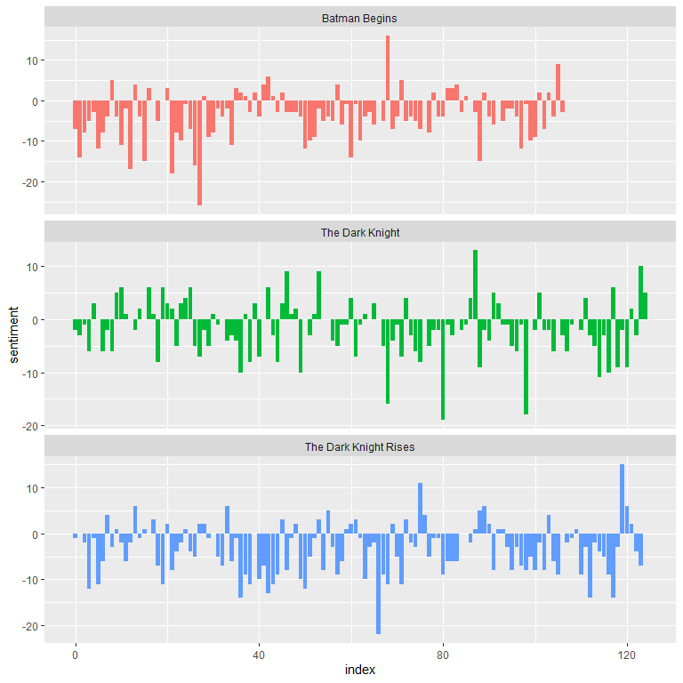

```r
bind_rows(afinn_begins, afinn_dk, afinn_dk_rises) %>%
   ggplot(aes(index, sentiment, fill = episode)) +
   geom_col(show.legend = FALSE) +
   facet_wrap(~episode, ncol = 1, scales = "free_y")
```

```r
begins_tidy %>%
   inner_join(get_sentiments("afinn")) %>%
   summarize(sentiment = sum(value))
```

```
## # A tibble: 1 x 1
##   sentiment
##       <dbl>
## 1      -409
```

```r
dk_tidy %>%
   inner_join(get_sentiments("afinn")) %>%
   summarize(sentiment = sum(value))
```

```
## # A tibble: 1 x 1
##   sentiment
##       <dbl>
## 1      -198
```

```r
dk_rises_tidy %>%
   inner_join(get_sentiments("afinn")) %>%
   summarize(sentiment = sum(value))
```

```
## # A tibble: 1 x 1
##   sentiment
##       <dbl>
## 1      -411
```

Lets try to visualize the sentiment scores and how frequent those words appear. For this I calculated the ‘contribution’ of each word - based on the afinn lexicon - , which is a multiplication of a word’s value and its number of occurrence in the text.

```r
count_afinn <- bind_rows(mutate(begins_df, episode = "Batman Begins"),
                     mutate(dk_df, episode = "The Dark Knight"),
                     mutate(dk_rises_df, episode = "The Dark Knight Rises")) %>%
   unnest_tokens(word, text) %>%
   filter(!is.na(word))

afinn_values <- count_afinn %>%
   inner_join(get_sentiments("afinn")) %>%
   count(episode, word, value, sort = TRUE) %>%
   ungroup()
```

Surprising to see love among the positive words, and ‘yeah’ for some reason. The reason for this might be that the text captures rather real life conversations and it is most probably a reassuring word.On the negatives ‘killed’ and ‘kill’ could be merged and then definitely that would be the highest contributor to the negative sentiments.

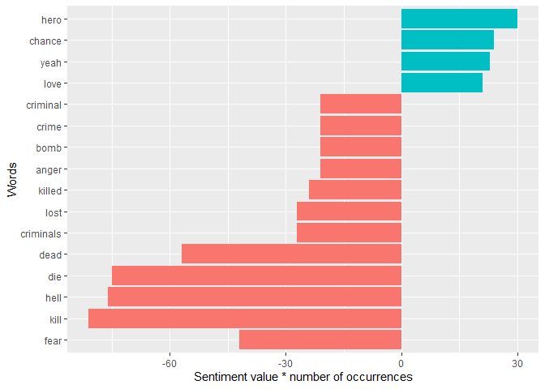

```r
afinn_values %>%
   anti_join(stop_words, by = "word") %>%
   mutate(contribution = n * value) %>%
   arrange(desc(abs(contribution))) %>%
   head(20) %>%
   mutate(word = reorder(word, contribution)) %>%
   ggplot(aes(n * value, word, fill = n * value > 0)) +
   geom_col(show.legend = FALSE) +
   labs(x = "Sentiment value * number of occurrences",
       y = "Words")
```

With a bit different pipeline and approach we arrive at the same negative, but different positive words.

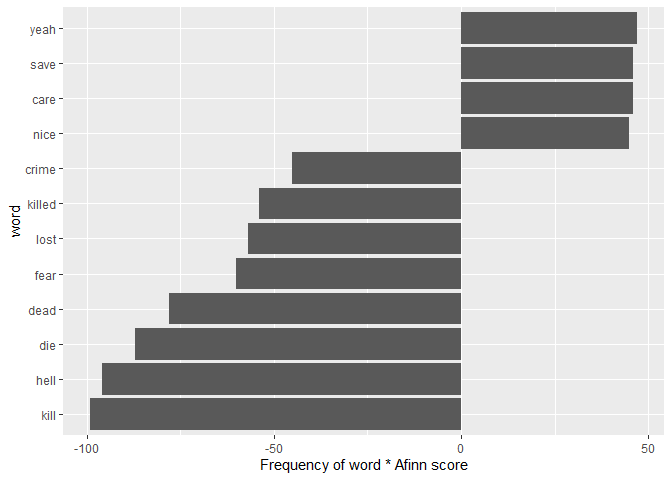

```r
count_afinn %>%
   anti_join(stop_words, by = "word") %>%
   count(word,episode,sort = TRUE) %>%
   inner_join(get_sentiments("afinn"), by = "word") %>%
   group_by(word) %>%
   summarize(contribution = sum(n * value)) %>%
   top_n(12, abs(contribution)) %>%
   mutate(word = reorder(word, contribution)) %>%
   ggplot(aes(word, contribution)) +
   geom_col() +
   coord_flip() +
   labs(y = "Frequency of word * Afinn score")
```

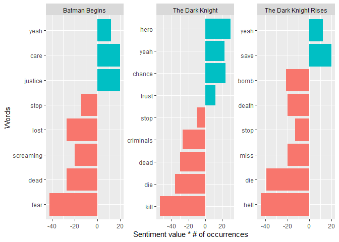

```r
afinn_values %>%
   anti_join(stop_words, by = "word") %>%
   mutate(contribution = n * value,
         word = reorder(word, contribution)) %>%
   group_by(word) %>%
   head(25) %>%
   slice_max(abs(contribution), n = 12, with_ties = FALSE) %>%
   ggplot(aes(word, contribution, fill = n * value > 0)) +
   geom_col(show.legend = FALSE) +
   facet_wrap(~ episode, scales = "free") +
   scale_x_discrete(labels = function(x) gsub("__.+$", "", x)) +
   xlab("Words") +
   ylab("Sentiment value * # of occurrences") +
   coord_flip()
```

Lastly I looked at bigrams, which reflect how important the particular 2-word expression is to a document in a corpus, we might find some context for the episodes.

```r
bigrams <- bind_rows(mutate(begins_df, episode = "Batman Begins"),
                     mutate(dk_df, episode = "The Dark Knight"),
                     mutate(dk_rises_df, episode = "The Dark Knight Rises")) %>%
   unnest_tokens(bigram, text, token = "ngrams", n = 2) %>%
   filter(!is.na(bigram))

bigrams = filter(bigrams, line != "2174" & line != "1122")

# separate the two words into two columns so we can join the stop words dictionary to each of them separately
bigrams_separated <- bigrams %>%
   separate(bigram, c("word1", "word2"), sep = " ")

bigrams_filtered <- bigrams_separated %>%
   filter(!word1 %in% stop_words$word) %>%
   filter(!word2 %in% stop_words$word)

bigram_counts <- bigrams_filtered %>%
   count(episode, word1, word2, sort = TRUE)

bigram_counts %>% head(12)
```

```
## # A tibble: 12 x 4
##    episode               word1   word2           n
##    <chr>                 <chr>   <chr>       <int>
##  1 The Dark Knight       harvey  dent           19
##  2 The Dark Knight Rises bruce   wayne          13
##  3 The Dark Knight Rises harvey  dent           11
##  4 Batman Begins         al      ghul            9
##  5 Batman Begins         ra's    al              9
##  6 The Dark Knight Rises wayne   enterprises     9
##  7 Batman Begins         bruce   wayne           8
##  8 Batman Begins         master  wayne           8
##  9 Batman Begins         water   supply          8
## 10 The Dark Knight Rises ra's    al              8
## 11 Batman Begins         dr      crane           6
## 12 Batman Begins         foreign language        6
```

```r
bigrams_united <- bigrams_filtered %>%
   unite(bigram, word1, word2, sep = " ")

bigram_tf_idf <- bigrams_united %>%
   count(episode, bigram) %>%
   bind_tf_idf(bigram, episode, n) %>%
   arrange(desc(tf_idf))
```

From these graphs it became obvious that one mistake I made is that I did not exclude such line which were just annotations to the subtitle, e.g. ‘Officer 2’ - indicating the person who was talking or ‘Speaking foreign language’ when in the film someone speaks other language than English. These are definitely not part of any conversation and should not be considered. Although we can see that for instance water supply is not mentioned a lot of times but is important in the first episode. Strange to see ‘harvey dent’ appearing in both second and third episode, I would have expected only unique bigrams which are not common for the episodes.

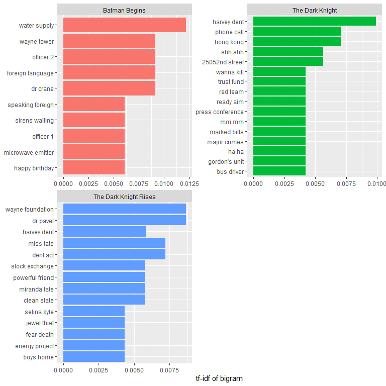

```r
bigram_tf_idf %>%
   arrange(desc(tf_idf)) %>%
   group_by(episode) %>%
   slice_max(tf_idf, n = 10) %>%
   ungroup() %>%
   mutate(bigram = reorder(bigram, tf_idf)) %>%
   ggplot(aes(tf_idf, bigram, fill = episode)) +
   geom_col(show.legend = FALSE) +
   facet_wrap(~ episode, ncol = 2, scales = "free") +
   labs(x = "tf-idf of bigram", y = NULL)
```